```python
from transformers import pipeline
```

# text summarization

```python
summarizer = pipeline(task="summarization", model="facebook/bart-large-cnn")
```

```python
text = "I’m really excited about the chance to work at Discord because I love how it brings people together—especially around games. I think Discord plays such a unique and important role in online communities, and I’d love to be part of a team that’s making those experiences better with data. The work sounds like a great match for what I enjoy doing: digging into metrics, designing thoughtful experiments, building clean dashboards, and collaborating across teams to make meaningful product decisions. I’m especially drawn to how much you care about users and the quality of their experience—I'd be thrilled to contribute to that."

# clean_up_tokenization_spaces cleans up the extra spaces.
summary = summarizer(text, max_length=50, min_length=30, do_sample=False, clean_up_tokenization_spaces=True)
```

```python
print(summary)
```

```python
summary[0]["summary_text"]
```

# using pre-trained LLMs

- `eos_token_id` end of sequence token id. it's learned through training.
- `pad_token_id` fills up the empty space up to the specified max length.
  - padding is adding tokens at the end of a sequence if necessary. if all the sequences are the same length, it ensures model efficiency
- `truncation = True` can be added if the input is longer than the max_length. It tells the model when to stop generating up to the specified length or the end of sequence

```python
generator = pipeline(task="text-generation", model="distilgpt2")
prompt = "The Gion Neighborhood in Kyoto is famous for"

output = generator(prompt, max_length=100, pad_token_id=generator.tokenizer.eos_token_id)

print(output[0]['generated_text'])
```

## guiding the output

```python
generator = pipeline(task="text-generation", model="distilgpt2")

review = " This book was great. I enjoyed the plot twist in Chapter 10."
response= "Dear reader, thank you for the review."

prompt = f"Book review:\n{review}\n\n Book shop response to the review:\n{response}"

output = generator(prompt, max_length=100, pad_token_id=generator.tokenizer.eos_token_id)

print(output[0]["generated_text"])
```

## language translation

```python
translator = pipeline(task="translation_en_to_es", model="Helsinki-NLP/opus-mt-en-es")

text = "Walking amid Gion's Machiya wooden houses was a mesmerizing experience."

output = translator(text, clean_up_tokenization_spaces=True)

print(output[0]["translation_text"])
```

# understanding the transformers

- are deep learning architectures
- processing, understanding, and generating text
- used in most llms
- it can handle longer text sequences in parallel rather than processing each word sequentially
- three common architectures, where each architecture specializes in a specific task:
  1. **encoder-only**: understanding the input text, without producing a sequecial output (a sentence) e.g. text classification, sentiment analysis, extractive question-answering (extract of a text or label)
  - BERT models
  - example: *distilbert-base-uncased-distilled-squad*
  2. **decoder-only**: Focuses on the output, making it ideal for generative tasks such as text generator, generative question-answering, where the answer is a sentence(s) or paragraphs(s)
  - GPT models
  - example: *gpt-3.5-turbo*
  3. **encoder-decoder**: It's a combination of the two. It helps the model understand and process the input and output for tasks like language translation, and text-summarization.
  - T5, BART models

## Identifying the model architecture

```python
llm = pipeline(model="bert-base-uncased")
print (llm.model)
```

```python
print(llm.model.config)
```

```python
print(llm.model.config.is_decoder)
```

```python
llm.model.config.is_encoder_decoder
```

```python
# the gpt model is tricky, we need to rely on our knowledge.
# the word of text-generation lets us know that is might be a decoder.
llm = pipeline(model="gpt2")
print(llm.model.config)
```

```python
# even if the function below returns false, examining the usage and the architecture lets us know that it's a decoder only
print(llm.model.config.is_decoder)
```

```python
llm = pipeline(model="Helsinki-NLP/opus-mt-es-en")
print(llm.model)
```

```python
print(llm.model.config)
```

```python
print(llm.model.config.is_encoder_decoder)
```

# Preparing for fine-tuning

`pipeline()`

- streamline language tasks
- autimatically select a model and tokenizer
- offers limited control

`Auto classes (AutoModel class)`

- offers more customization
- enable manual adjustments and fine-tuning

**LLM Development Lifecycle**

- Pre-training
  - on a broad dataset to learn general language patterns
- Fine-tuning
  - on a domain speciifc data to adapt it for specialized tasks

## loading a dataset for finetuning

```python
pip install --upgrade datasets
```

```python
# review classification

# load_dataset loads data from Hugging Face Hub
# finetune a pre-trained model with imdb data
from datasets import load_dataset

# we use shard to split the data into 4 chunks
# select the first chunk to save with index equals zero
train_data = load_dataset("imdb", split="train")
train_data = train_data.shard(num_shards=4, index=0)

test_data = load_dataset("imdb", split="test")
test_data = test_data.shard(num_shards=4, index=0)
```

```python
from transformers import AutoTokenizer, AutoModel
from transformers import AutoModelForSequenceClassification

model = AutoModelForSequenceClassification.from_pretrained("bert-base-uncased")
tokenizer = AutoTokenizer.from_pretrained("bert-base-uncased")

# tokenize the data
# truncation when it excceeds the specified max length for efficiency
# pt = pytorch tensors
# tokenized_training_data = tokenizer(train_data["text"], padding=True, truncation=True, return_tensors="pt", max_length=64)
# tokenized_test_data = tokenizer(test_data["text"], padding=True, truncation=True, return_tensors="pt", max_length=64)

def tokenize_function(examples):
  return tokenizer(examples["text"], padding="max_length", truncation=True, max_length=64)

tokenized_training_data = train_data.map(tokenize_function, batched=True)
tokenized_test_data = test_data.map(tokenize_function, batched=True)
```

```python
# truncated list of token ids
print(tokenized_training_data)
```

## Tokenize row by row

- if more control is needed we can tokenize a dataset in batches or row by row with a custom function and .map() method, setting batches to True or False, respectively.

```python
def tokenize_function(text_data):
  return tokenizer(text_data["text"], return_tensors="pt", padding=True, truncation=True, max_length=64)

# tokenize in batches
tokenized_in_batches = train_data.map(tokenize_function, batched=True)
print(tokenized_in_batches)

# tokenize row by row
tokenized_by_row = train_data.map(tokenize_function, batched=False)
# the result is a new dataset object with new columns with tokenized data for the training loop
print(tokenized_by_row)
```

## Subword tokenization:

The tokenization method that we've performed is known as the subword tokenization,

- common in modern tokenizers
- words split into meaningful sub-parts.e.g. "unbelievably" = > "unbelieve", "ably"

# Fine-tuning through Training

- with the data prepared, the next step id to set up our training arguments and loop.

## Training Arguments()

- This class allows customization to balance efficiency and performance. The values of these arguments depend on the use case, dataset size, and speed requirements.

-`output_dir:` output directory to save model predictions

- `evaluation_strategy()` determines when to evaluate during training:
  - `"epoch"`: (evaluate at the end of each epoch or after one complete pass of the full training dataset. This is useful if the dataset is small)
  - `"steps"`: evaluation is logged at every value of the `eval_steps` (if defined)
  - `"none"`: there could be no evaluation during trianing.
- `num_train_epochs:` the number of training epochs
- `learning rate`: The learning rate for the optimizer.
- `per_device_train_batch_size`=8
- `per_device_eval_batch_size`=8
- `weight_decay`=0.01: if we are doing fine-tuning with a small dataset, this small value helps us avoid overfitting.

```python
# !pip install transformers==4.31.0 datasets==2.14.4 peft==0.5.0
```

```python
from transformers import TrainingArguments, Trainer
```

```python
training_args = TrainingArguments(
    output_dir="./finedtuned/",
    evaluation_strategy="epoch",
    num_train_epochs=1,
    learning_rate=2e-5,
    per_device_train_batch_size=16,
    per_device_eval_batch_size=16,
    weight_decay=0.01
)
```

# Trainer class

- With the training arguments set up, then we pass this object to a Trainer class instance.
- `model`: the model to fine-tune.
- `args`: the training arguments. Set our training arguments to args parameter.
- `train_dataset`: define train data.
- `eval_dataset`: the data for evaluation.
- `processing_class`: specify the tokenizer to ensure our preprocessing is always consistent.
- instantiate a training loop with the `.train()` method.
  - `num_train_epochs`, `per_device_train_batch_size`, `per_device_eval_batch_size` detmine the number of loops.
  - the output of the `trainer.train()` tells us how the training process is going. We expect the loss to decrease.

```python
trainer = Trainer (
    model=model,
    args=training_args,
    train_dataset=tokenized_training_data,
    eval_dataset=tokenized_test_data,
    tokenizer=tokenizer # use processing_class instead
)

trainer.train()
# the model is now fine-tuned.
```

## Using fine-tuned Model

We can use the fine-tuned model to make predictions on new data.

1. prepare the new input data using the same tokenizer
2. before passing this inputs through the fine tuned model, we wrap this process in `torch.no_grad()` to disable gradient tracking since these aren't needed for evaluation.
3. We extract the predicted class with `.argmax()` and print them using a for loop for better readability.

```python
import torch # Import the torch library

new_data = ["This movie was disappointing", "This is the best Movie ever!"]

# tokenize the new data.
new_input = tokenizer(new_data, padding=True, truncation=True, return_tensors="pt", max_length=64)

# disable gradient tracking.
with torch.no_grad():
  output = model(**new_input)

predicted_labels = torch.argmax(output.logits, dim=1).tolist()

label_map = {0: "Negative", 1: "Positive"}

for i, predicted_label in enumerate(predicted_labels):
  sentiment = label_map[predicted_label]
  print(f"\nInput Text: {i + 1}: {new_data[i]}")
  print(f"\nPredicted Label: {sentiment}\n")

print(output)
```

## Saving models and tokenizers

```python
model.save_pretrained("./my_finetuned_model/")
tokenizer.save_pretrained("./my_finetuned_model/")
```

## reload the saved model

```python
model = AutoModelForSequenceClassification.from_pretrained("./my_finetuned_model/")
tokenizer = AutoTokenizer.from_pretrained("./my_finetuned_model/")
```

# Fine-tuning Approaches

- Fine tuning involves taking a pre-trained model and re-trianing it with domain specific data to solve a particular downstream task.
- Example: Consider a general purpose summarization model fine-tuned on a dataset of chemistry articles to specilize in summarizing chemistry papers.
- There are two finetuning approaches depending on *how the model weights are updated*:
  - **full finetuning:** which entails updating weights across the entire model (computationally expensive)
  - **partial finetuning:** where weights in lower layers of the model body that are responsible for capturing general language understanding, remain fixed. We only update the task-specific layers only.
- **Transfer learning** adapts a previously trained model on one task to a different but related rask.
  - Fine tuning typically involves training on a smaller dataset for a specific task, transfer learning leverages knowledge gained in one domain to enhance performance in another related domain.
  - several approaches can be adopted for transfer learning inclusing full, partial fine-tuning, zero-shot learning, one-shot learning, few-shot learning, etc.
    - n-shot learning: zero-, one-, few- shot learning. This is where a model is trained to generalize to a new task based on the number of examples it has been seen during training.
      - zero-shot learning is often used when data are scare, so a model is trained to generalize to new tasks never seen during training. We can provide explanations for the model so it's able to figure out the task.
      - Exposing the model to one or a few specific examples is known as one-shot and few-shot learning.

## one-shot learning

```python
from transformers import pipeline

generator = pipeline(task="sentiment-analysis", model="distilbert-base-uncased-finetuned-sst-2-english")

input_text="""Classify the sentiment of this sentence as either Positive or Negative.
Example:
Text: "I'm feeling great today!" Sentiment: Positive
Text: "The weather today is lovely." Sentiment:
"""

result = generator(input_text, max_length=100)
print(result[0]["label"])
```

# The evaluate Library

Language tasks usually require more comprehensive and task-specifc metrics. `Hugging Face's` evaluate library is used for this purpose.

- Metric: evaluate model performance based on ground truth
- Comparision: compare two models
- Measurement: insight on dataset properties

## Metric description

```python
# !pip install datasets
!pip install evaluate
```

```python
import evaluate
```

```python
accuracy = evaluate.load("accuracy")
print(accuracy.description)
```

## Feature attributes

By accessing the features attribute of a metric, we can ispenct the required inputs for its compuation.

```python
print(accuracy.features)
```

Most metrics often require two collections, predictions and references.

- `predictions`: model output
- `references`: ground truth
- `.feature`: indicates the data type supported for class labels, e.g. `int32` or `float32`, in metrics like accuracy and F1 score.

```python
f1 = evaluate.load("f1")
print(f1.features)
```

```python
pearson_corr = evaluate.load("pearsonr")
print(pearson_corr.features)
```

## LLM tasks and metrics

- Text classification
  - Accuracy
  - F1 Score
- Text generation
  - Perplexity
  - BLEU score
- Summarization
  - ROUGE score
  - BLEU score
- Translation
  - METEOR
  - BLEU
- Question-Answering
  - Extractive QA (answers a questions with an extract or label)
    - Exact Match (EM) + F1 score
  - Generative QA (generates a full textual answer)
    - BLEU/ROUGE

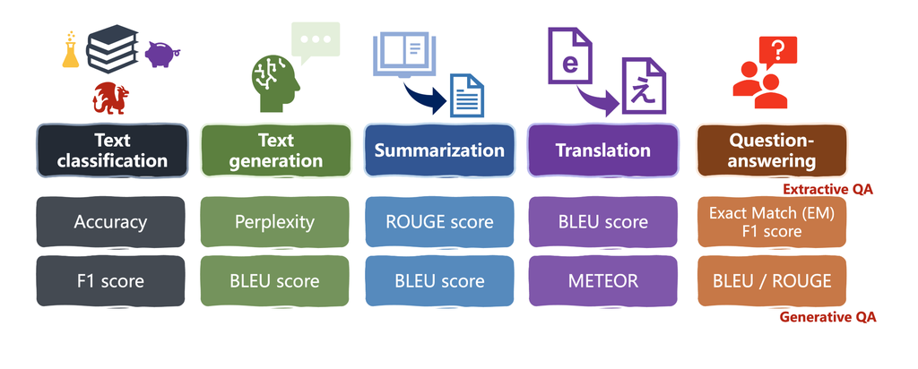

### Classification metrics

```python
accuracy = evaluate.load("accuracy")
precision = evaluate.load("precision")
recall = evaluate.load("recall")
f1 = evaluate.load("f1")
```

```python
from transformers import pipeline
from transformers import AutoTokenizer, AutoModel
from transformers import AutoModelForSequenceClassification

model = AutoModelForSequenceClassification.from_pretrained("bert-base-uncased")
tokenizer = AutoTokenizer.from_pretrained("bert-base-uncased")


evaluation_text = """Classify the sentiment of this sentence as either Positive or Negative.
Example:
Text: "I'm feeling great today!" Sentiment: Positive
Text: "The weather today is lovely." Sentiment:
"""
# initialize a pipeline with a model and tokenizer
classifier = pipeline("text-classification", model=model, tokenizer=tokenizer)
predictions = classifier(evaluation_text)

prediction_labels = [1 if pred["label"] == "POSITIVE" else 0 for pred in predictions]

print(prediction_labels)
```

### Metric outputs

```python
real_labels = [0, 1, 0, 1, 1]
predicted_labels = [0, 0, 0, 1, 1]


print(accuracy.compute(predictions=predicted_labels, references=real_labels))
print(precision.compute(predictions=predicted_labels, references=real_labels))
print(recall.compute(predictions=predicted_labels, references=real_labels))
print(f1.compute(predictions=predicted_labels, references=real_labels))
```

### Example: Evaluating our fine-tuned model

```python
# Load saved model and tokenizer with
# .from_pretrained("my_finetuned_files")
import torch

new_data = ["This movie was disappointing",
            "This is the best movie ever"]

new_input = tokenizer(new_data,
                      padding=True,
                      truncation=True,
                      return_tensors="pt",
                      max_length=64)

with torch.no_grad():
  output = model(**new_input)

predicted = torch.argmax(output.logits, dim=1).tolist()

real = [0, 1]
print(accuracy.compute(predictions=predicted, references=real))
print(precision.compute(predictions=predicted, references=real))
print(recall.compute(predictions=predicted, references=real))
print(f1.compute(predictions=predicted, references=real))
```

### Metrics for language tasks

#### Perplexity

```python
import torch
from transformers import AutoTokenizer, GPT2LMHeadModel

tokenizer = AutoTokenizer.from_pretrained("openai-community/gpt2")
model = GPT2LMHeadModel.from_pretrained("openai-community/gpt2")


input_text = "Latest research findings in Antractica show"
references = "Latest research findings in Antractica show that the ice sheet is melting faster than previously thought"

# Encode the prompt, generate text and decode it
# input -> tokenids, then back into text for output
input_text_ids = tokenizer.encode(input_text, return_tensors="pt")
output = model.generate(input_text_ids, max_length=20)
generated_text = tokenizer.decode(output[0], skip_special_tokens=True)


perplexity = evaluate.load("perplexity", module_type="metric")
results = perplexity.compute(predictions=generated_text, references=references, model_id="gpt2")
print(results)
print("mean perplexity:", results["mean_perplexity"])
```

```python
results.keys()
```

```python
perplexity.description
```

```python
perplexity.features
```

#### BLEU

- `BLEU` can also be used to evaluate `text generation`, as well as `summarization` and `translation`.
- it measures the quality of an LLMs outputs against some references provided by humans.
  - `predictions`: LLM's output
  - `References`: human references
  - output is between 0 and 1, indicating how similar the translation is to the reference. Values closer to 1 show higher similarity.

```python
bleu = evaluate.load("bleu")

input_text = "Latest research findings in Antractica show"
generated_text = "Latest research findings in Antractica show that the ice sheet is melting faster than previously thought"

references = ["Latest research findings in Antractica show significant ice loss due to climate change",
               "Latest research findings in Antractica show that the ice sheet is melting faster than previously thought"]

results = bleu.compute(predictions=[generated_text], references=[references])
print(results)
```

```python
bleu.description
```

```python
bleu.features
```

#### ROUGE

- `ROUGE` score is the most popular technique for evaluating text summarization, `BLEU` is useful for this task as well.
- It measures similarity between model-generated and reference summaries by ***analyzing n-gram co-occurances and word overlap***.
- ROUGE will provide us a set of metric scores capturing different aspects of text similarity.
  - rouge1: unigram (one word) overlap
  - rouge2: bigram (two words) overlap
  - rougeL: long overlapping subsequences
  - rougesum: a variant of rougeL (for summarization)
- Scores between 0-1: higher score indicates higher similarity

```python
!pip install rouge_score
```

```python
import rouge_score

rouge = evaluate.load("rouge")

predictions = "as we learn about the frequency and size of distribution of exoplanets, we are discovering that terrestrial planets are exceedingly common"
references = "The mode we learn about the frequency and size distribution of exoplanets, the more confident we are that they are exceedingly common."

results = rouge.compute(predictions=[predictions], references=[references])
print(results)
```

```python
rouge.description
```

```python
rouge.features
```

#### METEOR

- It incorporates more linguistic features into evaluation like variations in words through stemming, capturing words with similar meanings, and penalizing errors in word order.
- 0-1 score: higher is better. Higher scores indicate more semantic alignment
- It evaluates some of the more semantic features in text.
- good for generative QA

```python
# comparision of BLEU and METEOR
bleu = evaluate.load("bleu")
meteor = evaluate.load("meteor")

predicitons = "He thought it right and necessary to become a knight-errant, roaming the world in armor, seeking adventures and practicing the deeds he had read about in chivalric tales"
references= "He believed it was proper and essential to transform into a knight-errant, traveling the world in armor, pursuing adventures, and enacting the heroic deeds he had encountered in tales of chivalry."

bleu_score = bleu.compute(predictions=[predicitons], references=[references])
meteor_score = meteor.compute(predictions=[predicitons], references=[references])

print("BLEU Score:", bleu_score['bleu'])
print("METEOR Score:", meteor_score['meteor'])
```

#### EM (Exact Match)

- good for extractive QA
- Given a list of answers extracted by our model, and their associated reference answers, EM returns 1, if the model output exactly matches its associated reference answer, or 0 otherwise.
- Since it is highly sensitive, it is frequently used in combination with F-1 score rather than in isolation.

```python
exact_match = evaluate.load("exact_match")

predictions = ["The cat sat on the mat",
               'Theaters are great',
               "Like comparing oranges and apples"]

references= ["The cat sat on the mat?",
               'Theaters are great',
               "Like comparing apples and oranges"]

results = exact_match.compute(predictions=predictions, references=references)
print(results)
```

# Safegaurding LLMs

General challenges:

- `Multi-language support`: language diversity, resource availability, adaptability of the models to language
- `Open vs closed LLMs dilemma`: collaboration vs responsible use
- `Model scalability`: representation capabilities, computational demand, training requirements
- `biases`: biased training data, unfair language understanding and generation.
  - `Toxicity score`: quantifies text toxicity using pre-trained hate speech classifier. ***0-1 score*** per input, or *it returns the maximum of the inputs' toxicity* scores if the argument `'aggregation="maximum"'` is specified. Alternatively it can also return the percentage of input predictions with a toxicity score above 0.5, e.g. `aggregation=ratio`.
  - `Regard`:aims at quantifying the ***language polarity*** and biased perception towards certain demographics.
- `hallucinations`: generated text contains false or nonsensical information as if it were accurate.
  - Training on diverse balanced data helps this issue.
  - Bias audits on model outputs + bias removal techniques
  - fine-tuning to specific use cases in sensitive applications
  - prompt engineering: carefully crafting and refining prompts increases reliability and reduces hallucinations.

## Toxicity

```python
toxicity_metric = load("toxicity")

text_1 = ["Everyone in the team adores him", "He is a true genius, pure talent"]
text_2 = ["Nobody in the team likes him", "He is a useless 'good-for-nothing'"]

toxicity_result_1 = toxicity_metric.compute(predictions=text_1, aggregation="ratio")
# toxicity_result_1 = toxicity_metric.compute(predictions=text_1, aggregation="maximum")
toxicity_result_2 = toxicity_metric.compute(predictions=text_2, aggregation="maximum")

print("Toxicity sentence 1:", toxicity_result_1)
print("Toxicity sentence 2:", toxicity_result_2)
```

## Regard

```python
regard = evaluate.load("regard")

group1 = ["abc are described as loyal employees",
          "abc are ambitious in their career expectations"]
group2 = ["abs are known for causing lots of team conflicts",
          "abs are verbally violent"]

polarity_result_1 = regard.compute(data=group1)
polarity_result_2 = regard.compute(data=group2)
```

```python
for result in polarity_result_1['regard']:
  print(result)
```

```python
for result in polarity_result_2['regard']:
  print(result)
```

```python
regard_comp = evaluate.load("regard", "compare")
polarity_results_comp = regard_comp.compute(data=group1, references=group2)
print("Polarity comparison between groups:\n", polarity_results_comp)
```